# Music Suggestion

Amalia Purieka

2/24/2021

# Background

We are going to import data of music composition. Through the raw data, we will classify music suggestion using one of machine learning model. For the result, we will generate list of track that can be a suggestion based on previous track type.

# Data Pre-Processing

## Import Library

```r
# Import library
library(dplyr)
library(tidyr)
library(GGally)
library(gridExtra)
library(factoextra)
```

```r
library(FactoMineR)
library(plotly)
```

## Import Data

The data come from an online source which generated from spotify as well https://www.kaggle.com/zaheenhamidani/ultimate-spotify-tracks-db

```r
spotify <- read.csv("SpotifyFeatures.csv")
head(spotify)
```

```
##   genre       artist_name                       track_name
## 1 Movie    Henri Salvador      C'est beau de faire un Show
## 2 Movie Martin & les fées Perdu d'avance (par Gad Elmaleh)
## 3 Movie   Joseph Williams   Don't Let Me Be Lonely Tonight
## 4 Movie    Henri Salvador   Dis-moi Monsieur Gordon Cooper
## 5 Movie      Fabien Nataf                        Ouverture
## 6 Movie    Henri Salvador   Le petit souper aux chandelles
##                 track_id popularity acousticness danceability duration_ms
## 1 0BRjO6ga9RKCKjfDqeFgWV          0        0.611        0.389       99373
## 2 0BjC1NfoEOOusryehmNudP          1        0.246        0.590      137373
## 3 0CoSDzoNIKCRs124s9uTVy          3        0.952        0.663      170267
## 4 0Gc6TVm52BwZD07Ki6tIvf          0        0.703        0.240      152427
## 5 0IuslXpMROHdEPvSl1fTQK          4        0.950        0.331       82625
## 6 0Mf1jKa8eNAf1a4PwTbizj          0        0.749        0.578      160627
##   energy instrumentalness key liveness loudness  mode speechiness   tempo
## 1 0.9100            0.000  C#   0.3460   -1.828 Major      0.0525 166.969
## 2 0.7370            0.000  F#   0.1510   -5.559 Minor      0.0868 174.003
## 3 0.1310            0.000   C   0.1030  -13.879 Minor      0.0362  99.488
## 4 0.3260            0.000  C#   0.0985  -12.178 Major      0.0395 171.758
## 5 0.2250            0.123   F   0.2020  -21.150 Major      0.0456 140.576
## 6 0.0948            0.000  C#   0.1070  -14.970 Major      0.1430  87.479
##   time_signature valence
## 1            4/4   0.814
## 2            4/4   0.816
## 3            5/4   0.368
## 4            4/4   0.227
## 5            4/4   0.390
## 6            4/4   0.358
```

Let’s observe the data type using glimpse()

```r
glimpse(spotify)
```

```
## Rows: 232,725
## Columns: 18
## $ genre            <chr> "Movie", "Movie", "Movie", "Movie", "Movie", "Movie"…
## $ artist_name      <chr> "Henri Salvador", "Martin & les fées", "Joseph Willi…
## $ track_name       <chr> "C'est beau de faire un Show", "Perdu d'avance (par …
## $ track_id         <chr> "0BRjO6ga9RKCKjfDqeFgWV", "0BjC1NfoEOOusryehmNudP", …
## $ popularity       <int> 0, 1, 3, 0, 4, 0, 2, 15, 0, 10, 0, 2, 4, 3, 0, 0, 0,…
## $ acousticness     <dbl> 0.61100, 0.24600, 0.95200, 0.70300, 0.95000, 0.74900…
## $ danceability     <dbl> 0.389, 0.590, 0.663, 0.240, 0.331, 0.578, 0.703, 0.4…
## $ duration_ms      <int> 99373, 137373, 170267, 152427, 82625, 160627, 212293…
## $ energy           <dbl> 0.9100, 0.7370, 0.1310, 0.3260, 0.2250, 0.0948, 0.27…
## $ instrumentalness <dbl> 0.00e+00, 0.00e+00, 0.00e+00, 0.00e+00, 1.23e-01, 0.…
## $ key              <chr> "C#", "F#", "C", "C#", "F", "C#", "C#", "F#", "C", "…
## $ liveness         <dbl> 0.3460, 0.1510, 0.1030, 0.0985, 0.2020, 0.1070, 0.10…
## $ loudness         <dbl> -1.828, -5.559, -13.879, -12.178, -21.150, -14.970, …
## $ mode             <chr> "Major", "Minor", "Minor", "Major", "Major", "Major"…
## $ speechiness      <dbl> 0.0525, 0.0868, 0.0362, 0.0395, 0.0456, 0.1430, 0.95…
## $ tempo            <dbl> 166.969, 174.003, 99.488, 171.758, 140.576, 87.479, …
## $ time_signature   <chr> "4/4", "4/4", "5/4", "4/4", "4/4", "4/4", "4/4", "4/…
## $ valence          <dbl> 0.8140, 0.8160, 0.3680, 0.2270, 0.3900, 0.3580, 0.53…
```

Our data has 232725 Rows and 18 Columns

## Check Missing Data

```r
colSums(is.na(spotify))
```

```
##            genre      artist_name       track_name         track_id
##                0                0                0                0
##       popularity     acousticness     danceability      duration_ms
##                0                0                0                0
##           energy instrumentalness              key         liveness
##                0                0                0                0
##         loudness             mode      speechiness            tempo
##                0                0                0                0
##   time_signature          valence
##                0                0
```

Our data has no missing data

## Filter Popular Song

People will tend to pick a song from the popular one, well we filter as below

```r
spotify_filter <- spotify %>%
  filter(popularity>=80 & mode == "Major")

spotify_filter
```

```
##                genre                  artist_name
## 1        Alternative                         Joji
## 2        Alternative                         Joji
## 3              Dance                       Halsey
## 4              Dance                Ariana Grande
## 5              Dance                Ariana Grande
## 6              Dance                Ariana Grande
## 7              Dance                Ariana Grande
## 8              Dance                         Lauv
## 9              Dance                      Ava Max
## 10             Dance                Ariana Grande
## 11             Dance                    Lady Gaga
## 12             Dance                Ariana Grande
## 13             Dance                    Lady Gaga
## 14             Dance                Ariana Grande
```

[output cut: 3715 more lines]

## Remove Unnecessary Variables

In this case, we are going to analyse music suggestion based on the song’s sompostion from previous choice. Thus we need to remove the other non-related variable

```r
spotify_co <- spotify_filter %>%
 select(-c(artist_name, track_name, track_id, mode, time_signature, key, mode, duration_ms, genre, popularity, tempo))

head(spotify_co)
```

```
##   acousticness danceability energy instrumentalness liveness loudness
## 1       0.4220        0.552  0.650         2.75e-04   0.3720   -7.199
## 2       0.5440        0.515  0.479         5.98e-03   0.1910   -7.458
## 3       0.2970        0.752  0.488         9.11e-06   0.0936   -7.050
## 4       0.4510        0.747  0.458         0.00e+00   0.2520   -6.891
## 5       0.2800        0.724  0.647         0.00e+00   0.1020   -5.642
## 6       0.0268        0.847  0.579         5.45e-02   0.1020   -5.314
##   speechiness valence
## 1      0.1280   0.316
## 2      0.0261   0.284
## 3      0.0705   0.533
## 4      0.3030   0.470
## 5      0.0658   0.435
## 6      0.0719   0.569
```

# Exploratory Data Analysis

```r
summary(spotify_co)
```

```
##   acousticness       danceability        energy       instrumentalness
##  Min.   :0.000147   Min.   :0.2770   Min.   :0.1470   Min.   :0.0000000
##  1st Qu.:0.033500   1st Qu.:0.5940   1st Qu.:0.5200   1st Qu.:0.0000000
##  Median :0.137000   Median :0.6800   Median :0.6360   Median :0.0000000
##  Mean   :0.209465   Mean   :0.6766   Mean   :0.6379   Mean   :0.0037289
##  3rd Qu.:0.310000   3rd Qu.:0.7650   3rd Qu.:0.7680   3rd Qu.:0.0000102
##  Max.   :0.922000   Max.   :0.9420   Max.   :0.9530   Max.   :0.4330000
##     liveness         loudness        speechiness        valence
##  Min.   :0.0344   Min.   :-18.064   Min.   :0.0232   Min.   :0.0379
##  1st Qu.:0.0935   1st Qu.: -7.458   1st Qu.:0.0432   1st Qu.:0.2840
##  Median :0.1200   Median : -5.893   Median :0.0703   Median :0.4460
##  Mean   :0.1677   Mean   : -6.307   Mean   :0.1100   Mean   :0.4646
##  3rd Qu.:0.1940   3rd Qu.: -4.777   3rd Qu.:0.1450   3rd Qu.:0.6190
##  Max.   :0.7640   Max.   : -2.188   Max.   :0.5650   Max.   :0.9280
```

## Scale Data Variances

First, check the original variances

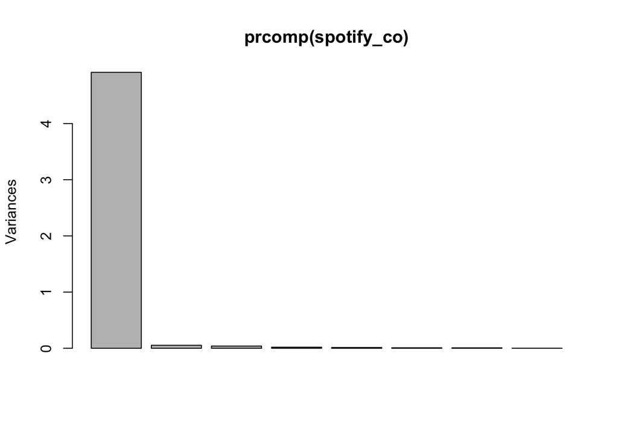

```r
plot(prcomp(spotify_co))
```

From the above chart, we know that gap in our data is quite high, we need to scale it

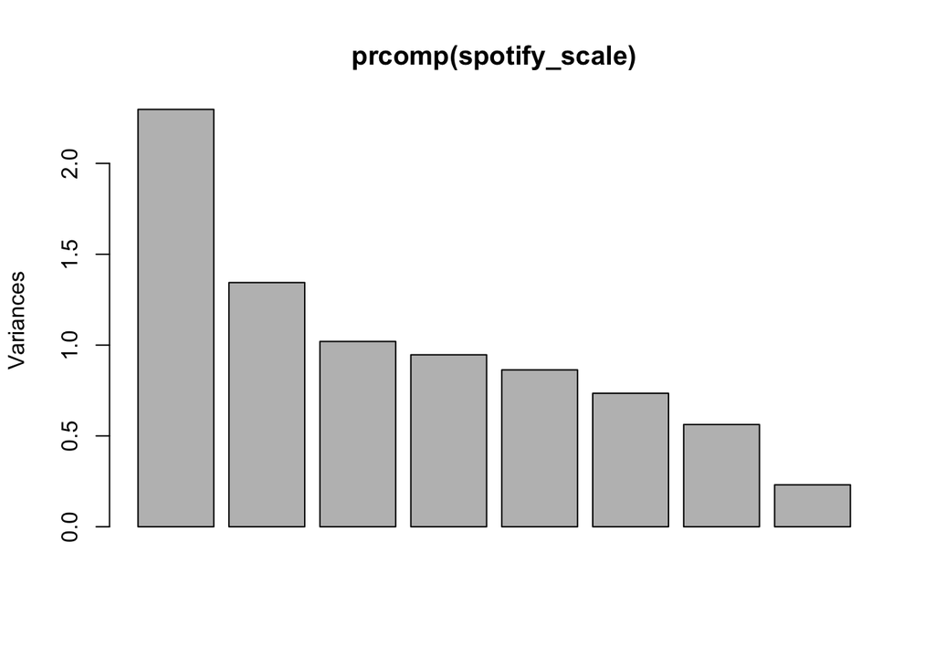

```r
# scaling
spotify_scale <- scale(spotify_co)

# check the PCA again
plot(prcomp(spotify_scale))
```

Now our data has normal gap.

# Model PCA

```r
#menggunakan data yang sudah discale
pca_spotify <- PCA(spotify_scale, scale. = F)
```

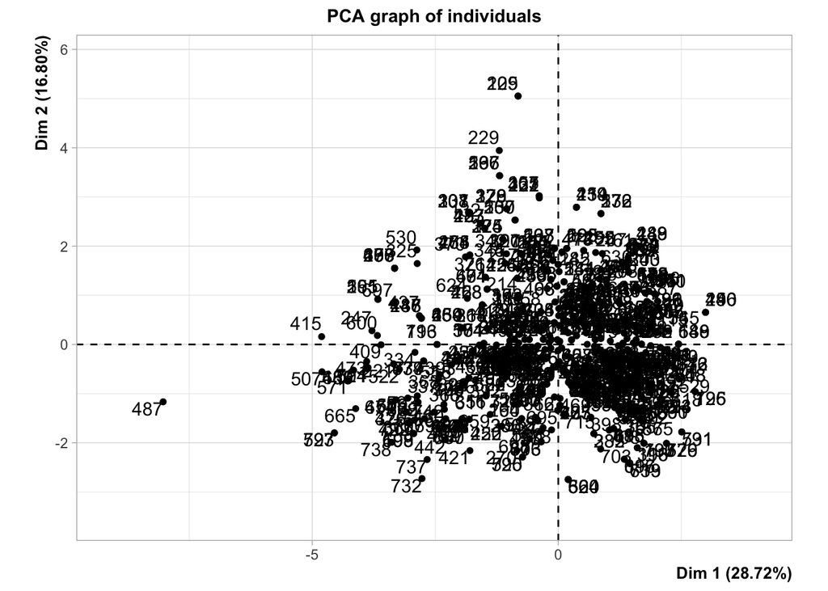

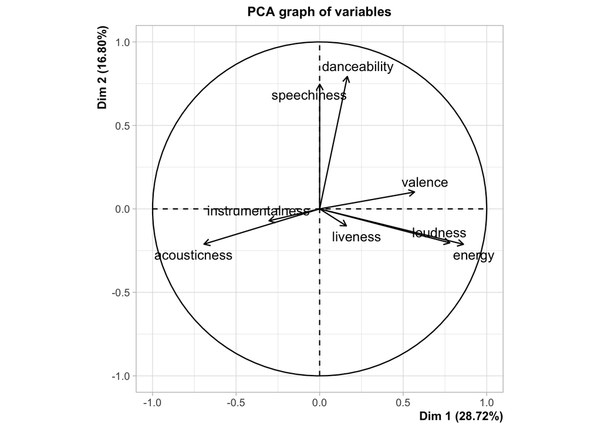

```r
pca_spotify
```

```
## **Results for the Principal Component Analysis (PCA)**
## The analysis was performed on 745 individuals, described by 8 variables
## *The results are available in the following objects:
##
##    name               description
## 1  "$eig"             "eigenvalues"
## 2  "$var"             "results for the variables"
## 3  "$var$coord"       "coord. for the variables"
## 4  "$var$cor"         "correlations variables - dimensions"
## 5  "$var$cos2"        "cos2 for the variables"
## 6  "$var$contrib"     "contributions of the variables"
## 7  "$ind"             "results for the individuals"
## 8  "$ind$coord"       "coord. for the individuals"
## 9  "$ind$cos2"        "cos2 for the individuals"
## 10 "$ind$contrib"     "contributions of the individuals"
## 11 "$call"            "summary statistics"
## 12 "$call$centre"     "mean of the variables"
## 13 "$call$ecart.type" "standard error of the variables"
## 14 "$call$row.w"      "weights for the individuals"
## 15 "$call$col.w"      "weights for the variables"
```

```r
summary(pca_spotify)
```

```
##
## Call:
## PCA(X = spotify_scale, scale.unit = F)
##
##
## Eigenvalues
##                        Dim.1   Dim.2   Dim.3   Dim.4   Dim.5   Dim.6   Dim.7
## Variance               2.294   1.342   1.019   0.945   0.862   0.734   0.562
## % of var.             28.718  16.803  12.750  11.832  10.794   9.183   7.033
## Cumulative % of var.  28.718  45.520  58.271  70.103  80.897  90.079  97.112
##                        Dim.8
## Variance               0.231
## % of var.              2.888
## Cumulative % of var. 100.000
##
## Individuals (the 10 first)
##                      Dist    Dim.1    ctr   cos2    Dim.2    ctr   cos2
## 1                |  2.332 | -0.763  0.034  0.107 | -0.852  0.073  0.134 |
## 2                |  2.556 | -1.954  0.223  0.584 | -1.513  0.229  0.350 |
## 3                |  1.446 | -0.722  0.031  0.250 |  0.374  0.014  0.067 |
## 4                |  2.693 | -1.081  0.068  0.161 |  1.650  0.272  0.376 |
## 5                |  0.937 | -0.001  0.000  0.000 | -0.123  0.002  0.017 |
## 6                |  2.718 |  0.276  0.004  0.010 |  0.744  0.055  0.075 |
## 7                |  3.546 | -0.662  0.026  0.035 |  0.454  0.021  0.016 |
## 8                |  1.501 |  0.371  0.008  0.061 |  0.179  0.003  0.014 |
## 9                |  1.482 |  1.233  0.089  0.692 | -0.200  0.004  0.018 |
## 10               |  1.737 | -0.732  0.031  0.178 | -0.276  0.008  0.025 |
##                   Dim.3    ctr   cos2
## 1                -1.669  0.367  0.512 |
## 2                -0.383  0.019  0.022 |
## 3                 0.449  0.027  0.096 |
## 4                -0.938  0.116  0.121 |
## 5                 0.531  0.037  0.321 |
## 6                 1.606  0.340  0.349 |
## 7                -1.704  0.382  0.231 |
## 8                -0.684  0.062  0.208 |
## 9                 0.262  0.009  0.031 |
## 10                0.311  0.013  0.032 |
##
## Variables
##                     Dim.1    ctr   cos2    Dim.2    ctr   cos2    Dim.3    ctr
## acousticness     | -0.692 20.879  0.480 | -0.211  3.315  0.045 |  0.074  0.541
## danceability     |  0.166  1.199  0.028 |  0.793 46.850  0.630 |  0.123  1.496
## energy           |  0.861 32.296  0.742 | -0.212  3.348  0.045 |  0.160  2.524
## instrumentalness | -0.303  3.997  0.092 | -0.071  0.378  0.005 |  0.478 22.454
## liveness         |  0.160  1.117  0.026 | -0.102  0.769  0.010 | -0.834 68.363
## loudness         |  0.779 26.450  0.608 | -0.203  3.074  0.041 |  0.121  1.428
## speechiness      |  0.001  0.000  0.000 |  0.746 41.506  0.558 | -0.118  1.372
## valence          |  0.568 14.063  0.323 |  0.101  0.762  0.010 |  0.136  1.823
##                    cos2
## acousticness      0.006 |
## danceability      0.015 |
## energy            0.026 |
## instrumentalness  0.229 |
## liveness          0.697 |
## loudness          0.015 |
## speechiness       0.014 |
## valence           0.019 |
```

# Choosing Optimum K

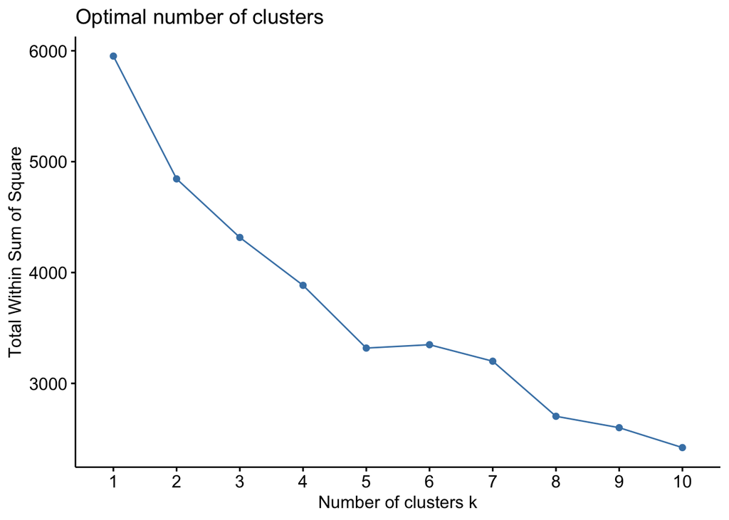

```r
fviz_nbclust(spotify_scale, kmeans, method = "wss")
```

# Clustering

In this process, K value will be implemented into clustering process. Create new column cluster for classification on each observations.

```r
# set.seed to ensure reproducible example
set.seed(101)

# use kmeans (centers=clusters, which is 6)
spotify_cluster <- kmeans(spotify_co, centers = 6)

# show how many observations on each cluster
data.frame(cbind(cluster=c(1:6), observation=spotify_cluster$size))
```

```
##   cluster observation
## 1       1          68
## 2       2         180
## 3       3         140
## 4       4         157
## 5       5         113
## 6       6          87
```

```r
spotify_filter$cluster <- spotify_cluster$cluster
spotify_co$cluster <- spotify_cluster$cluster
tail(spotify_filter)
```

```
##       genre    artist_name            track_name               track_id
## 740    Soul Rag'n'Bone Man                 Human 58zsLZPvfflaiIbNWoA22O
## 741    Soul    Leona Lewis         Bleeding Love 7wZUrN8oemZfsEd1CGkbXE
## 742 Country     Luke Combs       Beautiful Crazy 2rxQMGVafnNaRaXlRMWPde
## 743 Country       Sam Hunt Body Like A Back Road 7mldq42yDuxiUNn08nvzHO
## 744 Country Lynyrd Skynyrd    Sweet Home Alabama 7e89621JPkKaeDSTQ3avtg
## 745    Rock     Tom Walker      Leave a Light On 6lOWoTqVnAWXchddtTH31W
##     popularity acousticness danceability duration_ms energy instrumentalness
## 740         81       0.3930        0.602      200187  0.707         0.00e+00
## 741         80       0.1880        0.638      262467  0.656         0.00e+00
## 742         82       0.6760        0.552      193200  0.402         0.00e+00
## 743         80       0.4630        0.731      165387  0.469         1.04e-06
## 744         82       0.1810        0.596      283800  0.605         3.31e-04
## 745         81       0.0153        0.586      185863  0.624         1.78e-06
##     key liveness loudness  mode speechiness   tempo time_signature valence
## 740   B   0.1650   -4.097 Major      0.3020  75.090            4/4   0.554
## 741   F   0.1460   -5.886 Major      0.0357 104.036            4/4   0.225
## 742   B   0.0928   -7.431 Major      0.0262 103.313            4/4   0.382
## 743   F   0.1030   -7.226 Major      0.0326  98.963            4/4   0.631
## 744   G   0.0863  -12.145 Major      0.0255  97.798            4/4   0.886
## 745   F   0.1330   -5.946 Major      0.1130  68.976            4/4   0.267
##     cluster
## 740       5
## 741       2
## 742       4
## 743       4
## 744       1
## 745       2
```

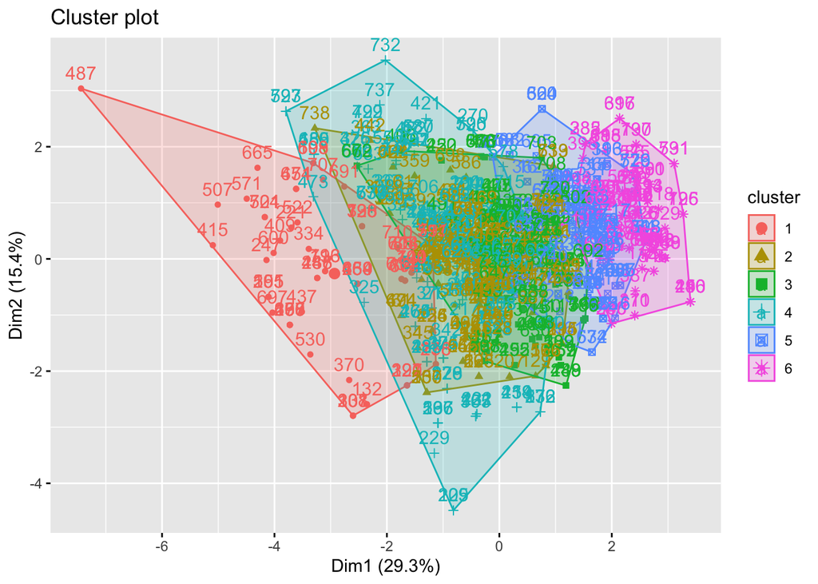

```r
fviz_cluster(object=spotify_cluster,
             data = spotify_co)
```

# Goodness of Fit

We can check the goodness of Fit using 3 values below:

## Within Sum of Squares tot.withins

Signify the ‘length’ from each observation to its centroid in each cluster

```r
spotify_cluster$tot.withinss
```

```
## [1] 351.3024
```

## Total Sum of Squares totss

Signify the ‘length’ from each observation to global sample mean

```r
# totss
spotify_cluster$totss
```

```
## [1] 3760.574
```

## Between Sum of Squares betweenss

Signify the ‘length’ from each centroid from each cluster to the global sample mean

```r
spotify_cluster$betweenss
```

```
## [1] 3409.271
```

Another ‘goodness’ measure can be signified with a value in betweenss/totss, the closer the value to 1 or 100%, the better:

```r
# `betweenss`/`tot.withinss`
((spotify_cluster$betweenss)/(spotify_cluster$totss))*100
```

```
## [1] 90.65828
```

Our model has good accuracy which above 90%. We will be able to hear music based on our previous type song of choice.

Well, let’s try to review our model of song’s suggestion.

```r
spotify_filter %>%
  group_by(cluster) %>%
  summarise_all(mean) %>%
  select(cluster, acousticness, danceability, energy, instrumentalness, speechiness, valence)
```

```
## # A tibble: 6 x 7
##   cluster acousticness danceability energy instrumentalness speechiness valence
##     <int>        <dbl>        <dbl>  <dbl>            <dbl>       <dbl>   <dbl>
## 1       1        0.403        0.643  0.435         0.0117        0.105    0.427
## 2       2        0.181        0.699  0.631         0.000117      0.102    0.446
## 3       3        0.165        0.679  0.670         0.00164       0.117    0.477
## 4       4        0.282        0.680  0.522         0.00909       0.133    0.377
## 5       5        0.162        0.670  0.745         0.00254       0.0987   0.533
## 6       6        0.120        0.654  0.831         0.000193      0.0924   0.581
```

```r
spotify_filter %>%
  filter(cluster == 2, genre == "Pop") %>%
  head(5)
```

```
##   genre   artist_name      track_name               track_id popularity
## 1   Pop        Halsey      Without Me 5p7ujcrUXASCNwRaWNHR1C         97
## 2   Pop Ariana Grande            NASA 4uTvPEr01pjTbZgl7jcKBD         91
## 3   Pop          Lauv i'm so tired... 7COXchtUOMd6uIT6HvmRaI         94
## 4   Pop   Post Malone      Better Now 7dt6x5M1jzdTEt8oCbisTK         93
## 5   Pop       Cardi B       Please Me 0PG9fbaaHFHfre2gUVo7AN         91
##   acousticness danceability duration_ms energy instrumentalness key liveness
## 1       0.2970        0.752      201661  0.488         9.11e-06  F#   0.0936
## 2       0.4510        0.747      182000  0.458         0.00e+00  F#   0.2520
## 3       0.1760        0.599      162583  0.733         0.00e+00   B   0.2420
## 4       0.3540        0.680      231267  0.563         0.00e+00  A#   0.1360
## 5       0.0642        0.747      200890  0.570         0.00e+00  C#   0.0832
##   loudness  mode speechiness   tempo time_signature valence cluster
## 1   -7.050 Major      0.0705 136.041            4/4   0.533       2
## 2   -6.891 Major      0.3030  75.029            4/4   0.470       2
## 3   -7.058 Major      0.2030 102.211            4/4   0.534       2
## 4   -5.843 Major      0.0454 145.028            4/4   0.374       2
## 5   -6.711 Major      0.0810 133.992            4/4   0.650       2
```

# Conclusion

Our model has generate accuracy above 90 % which means pretty good suggestion for our next song. Based on our clustering result, we also can use our model to initially set up music based on personal mood since the cluster of the model represent several music’s characteristic.